# A case study in HR analytics

Shubham

## Steps for text mining project

- **Problem Defination and Specific Goal**
- **Identify Text to be collected**
- **Text Organization**
- **Feature Extraction**
- **Analysis**
- **Reach an insight**

**Problem** :- Which company has better work life balance? Which has better perceived pay according to online reviews?We learn something about how employees review both Amazon and Google.

Employee reviews can come from various sources.Forbes and others publish articles about the “best places to work”, which may mention Amazon and Google. Another source of information might be anonymous online reviews from websites like Indeed, Glassdoor or CareerBliss.

Here, we’ll focus on a collection of anonymous online reviews of amazon and google.

```r
library(readr)
amazon <- read_csv("~/500_amzn.csv")
google <- read_csv("~/500_goog.csv")
```

```r
str(amazon)
```

```
## Classes 'tbl_df', 'tbl' and 'data.frame':    500 obs. of  4 variables:
##  $ pg_num: int  50 50 50 50 50 50 50 50 50 50 ...
##  $ url   : chr  "https://www.glassdoor.com/Reviews/Amazon-com-Reviews-E6036_P50.htm" "https://www.glassdoor.com/Reviews/Amazon-com-Reviews-E6036_P50.htm" "https://www.glassdoor.com/Reviews/Amazon-com-Reviews-E6036_P50.htm" "https://www.glassdoor.com/Reviews/Amazon-com-Reviews-E6036_P50.htm" ...
##  $ pros  : chr  "You're surrounded by smart people and the projects are interesting, if a little daunting." "Brand name is great. Have yet to meet somebody who is unfamiliar with Amazon. Hours weren't as bad as I had pre"| __truncated__ "Good money.Interaction with some great minds in the world d…
##  $ cons  : chr  "Internal tools proliferation has created a mess for trying to get to basic information. Most people are require"| __truncated__ "not the most stimulating work. Good brand name to work for but the work itself is mundane as it can get. As a f"| __truncated__ "No proper growth plan …
##  - attr(*, "spec")=List of 2
##   ..$ cols   :List of 4
##   .. ..$ pg_num: list()
##   .. .. ..- attr(*, "class")= chr  "collector_integer" "collector"
##   .. ..$ url   : list()
##   .. .. ..- attr(*, "class")= chr  "collector_character" "collector"
##   .. ..$ pros  : list()
##   .. .. ..- attr(*, "class")= chr  "collector_character" "collector"
##   .. ..$ cons  : list()
##   .. .. ..- attr(*, "class")= chr  "collector_character" "collector"
##   ..$ default: list()
##   .. ..- attr(*, "class")= chr  "collector_guess" "collector"
##   ..- attr(*, "class")= chr "col_spec"
```

```r
amazon_pros <- amazon$pros
amazon_cons <- amazon$cons
```

```r
str(google)
```

```
## Classes 'tbl_df', 'tbl' and 'data.frame':    501 obs. of  4 variables:
##  $ pg_num: int  1 1 1 1 1 1 1 1 1 1 ...
##  $ url   : chr  "https://www.glassdoor.com/Reviews/Google-Reviews-E9079_P1.htm" "https://www.glassdoor.com/Reviews/Google-Reviews-E9079_P1.htm" "https://www.glassdoor.com/Reviews/Google-Reviews-E9079_P1.htm" "https://www.glassdoor.com/Reviews/Google-Reviews-E9079_P1.htm" ...
##  $ pros  : chr  "* If you're a software engineer, you're among the kings of the hill at Google. It's an engineer-driven company "| __truncated__ "1) Food, food, food. 15+ cafes on main campus (MTV) alone. Mini-kitchens, snacks, drinks, free breakfast/lunch/"| __truncated__ "You can't find a more …
##  $ cons  : chr  "* It *is* becoming larger, and with it comes growing pains: bureaucracy, slow to respond to market threats, blo"| __truncated__ "1) Work/life balance. What balance? All those perks and benefits are an illusion. They keep you at work and the"| __truncated__ "I live in SF so the co…
##  - attr(*, "spec")=List of 2
##   ..$ cols   :List of 4
##   .. ..$ pg_num: list()
##   .. .. ..- attr(*, "class")= chr  "collector_integer" "collector"
##   .. ..$ url   : list()
##   .. .. ..- attr(*, "class")= chr  "collector_character" "collector"
##   .. ..$ pros  : list()
##   .. .. ..- attr(*, "class")= chr  "collector_character" "collector"
##   .. ..$ cons  : list()
##   .. .. ..- attr(*, "class")= chr  "collector_character" "collector"
##   ..$ default: list()
##   .. ..- attr(*, "class")= chr  "collector_guess" "collector"
##   ..- attr(*, "class")= chr "col_spec"
```

```r
google_pros <- google$pros
google_cons <- google$cons
```

**Text organization** Now that we have selected the exact text sources, we are now ready to clean them up. We’ll be using the two functions qdap_clean(), which applies a series of qdap functions to a text vector, and tm_clean(),which applies a series of tm functions to a corpus object.

```r
library(qdap)
qdap_clean <- function(x){
  x<- na.omit(x)
  x<- replace_abbreviation(x)
  x<- replace_contraction(x)
  x<- replace_number(x)
  x<- replace_ordinal(x)
  x<- replace_symbol(x)
  x<-tolower(x)
  return(x)
}
```

```r
library(tm)
```

```r
tm_clean <- function(x){
  x<-tm_map(x,removePunctuation)
  x<-tm_map(x,stripWhitespace)
  x<-tm_map(x,removeWords,c(stopwords("en"),"Amazon","Google","Company"))
  return(x)
}
```

Applying qdap_clean() to amazon and google

```r
amazon_pros <- qdap_clean(amazon_pros)
amazon_cons <- qdap_clean(amazon_cons)

google_pros <- qdap_clean(google_pros)
google_cons <- qdap_clean(google_cons)
```

Next step is to convert this vector containing the text data to a corpus. Corpus is a collection of documents, but it’s also important to know that in the tm domain, R recognizes it as a data type.

There are two kinds of the corpus data type, the permanent corpus, PCorpus, and the volatile corpus, VCorpus. In essence, the difference between the two has to do with how the collection of documents is stored in your computer.We will use the volatile corpus, which is held in computer’s RAM rather than saved to disk, just to be more memory efficient.

To make a volatile corpus, R needs to interpret each element in our vector of text, amazon_pros, as a document. And the tm package provides what are called Source functions to do just that! We’ll use a Source function called VectorSource() because our text data is contained in a vector. The output of this function is called a Source.

```r
amazon_p_corp <- VCorpus(VectorSource(amazon_pros))
amazon_c_corp <- VCorpus(VectorSource(amazon_cons))

google_p_corp <- VCorpus(VectorSource(google_pros))
google_c_corp <- VCorpus(VectorSource(google_cons))
```

Now using tm_clean to clean data

```r
amazon_pros_corp <- tm_clean(amazon_p_corp)
amazon_cons_corp <- tm_clean(amazon_c_corp)

google_pros_corp <- tm_clean(google_p_corp)
google_cons_corp <- tm_clean(google_c_corp)
```

**Steps 4 & 5: Feature extraction & analysis**

Since amzn_pros_corp, amzn_cons_corp, goog_pros_corp and goog_cons_corp have all been preprocessed, so now we can extract the features we want to examine. Since we are using the bag of words approach, we decide to create a bigram TermDocumentMatrix for Amazon’s positive reviews corpus, amzn_pros_corp. From this, we can quickly create a wordcloud() to understand what phrases people positively associate with working at Amazon.

The function below uses RWeka to tokenize two terms.

```r
library(RWeka)
tokenizer <- function(x)
  NGramTokenizer(x, Weka_control(min = 2, max = 2))
```

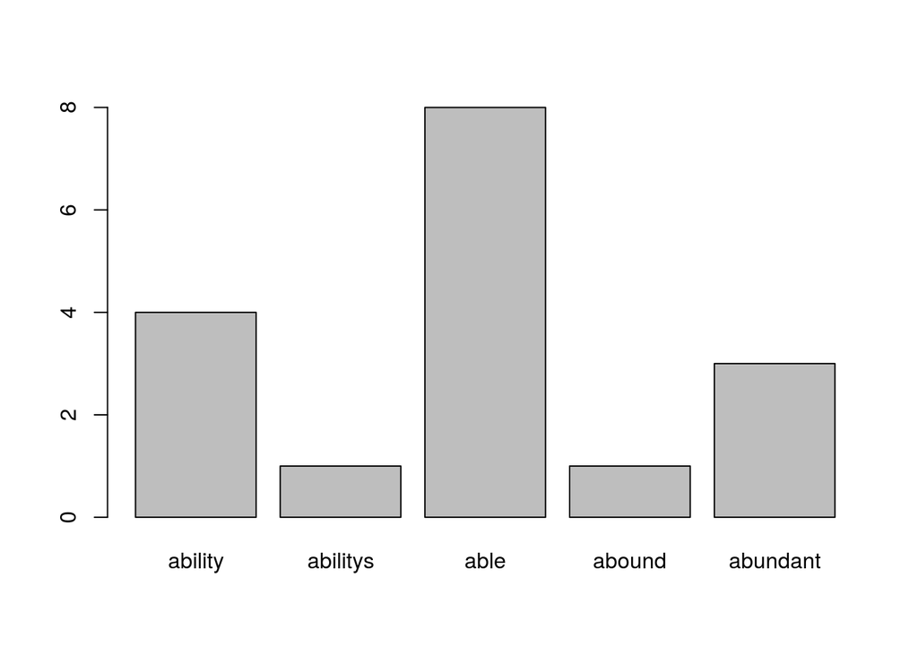

```r
amazon_p_tdm <- TermDocumentMatrix(amazon_pros_corp)
amazon_p_tdm_m <- as.matrix(amazon_p_tdm)
amazon_p_freq <- rowSums(amazon_p_tdm_m)
amazon_p_f.sort <- sort(amazon_p_freq,decreasing = TRUE)

barplot(amazon_p_freq[1:5])
```

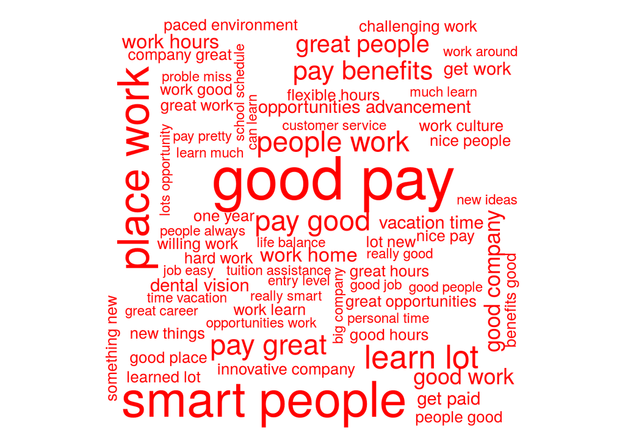

```r
library(wordcloud)
amazon_p_tdm <- TermDocumentMatrix(amazon_pros_corp,control = list(tokenize=tokenizer))
amazon_p_tdm_m <- as.matrix(amazon_p_tdm)
amazon_p_freq <- rowSums(amazon_p_tdm_m)
amazon_p_f.sort <- sort(amazon_p_freq,decreasing = TRUE)
p_df <- data.frame(term=names(amazon_p_f.sort),num=amazon_p_f.sort)

wordcloud(p_df$term,p_df$num,max.words=100,color="red")
```

Feature extraction & analysis: amazon_cons

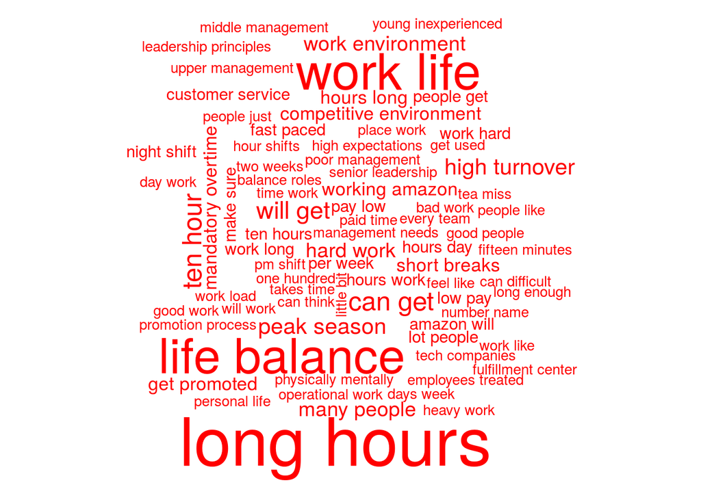

```r
amazon_c_tdm <- TermDocumentMatrix(amazon_cons_corp,control=list(tokenize=tokenizer))
amazon_c_tdm_m <- as.matrix(amazon_c_tdm)
amazon_c_freq <- rowSums(amazon_c_tdm_m)
amazon_c_f.sort <- sort(amazon_c_freq,decreasing = TRUE)
c_df <- data.frame(term=names(amazon_c_f.sort),num=amazon_c_f.sort)

wordcloud(c_df$term,c_df$num,max.words=100,color="red")
```

*amazon_cons dendrogram*

It seems there is a strong indication of long working hours and poor work-life balance in the reviews. As a simple clustering technique, we’ll decide to perform a hierarchical cluster and create a dendrogram to see how connected these phrases are.

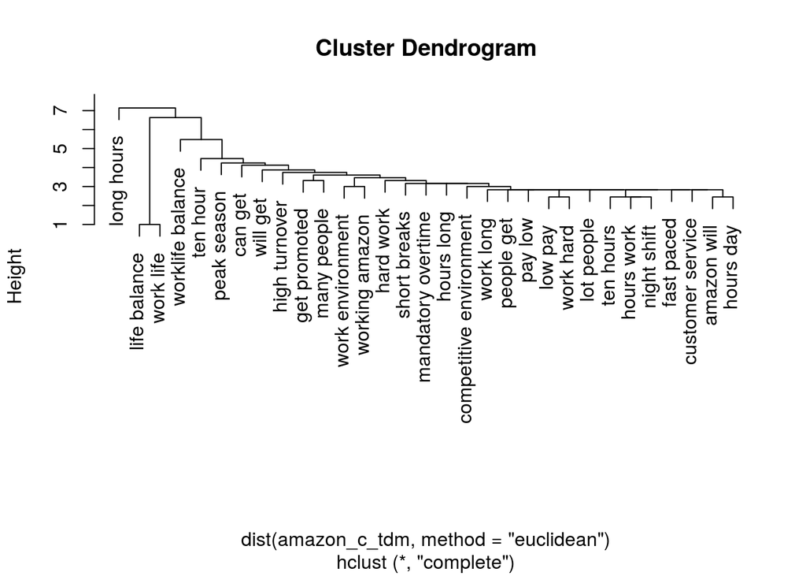

```r
amazon_c_tdm <- TermDocumentMatrix(amazon_cons_corp,control = list(tokenize=tokenizer))
amazon_c_tdm <- removeSparseTerms(amazon_c_tdm,0.993)

amazon_c_hclust <- hclust(dist(amazon_c_tdm,method="euclidean"),method="complete")

plot(amazon_c_hclust)
```

*Word association* Switching back to positive comments, we’ll decide to examine top phrases that appeared in the word clouds. We’ll now hope to find associated terms using the findAssocs() function from tm package.

```r
amazon_p_tdm <- TermDocumentMatrix(amazon_pros_corp,control=list(tokenize=tokenizer))
amazon_p_m <- as.matrix(amazon_p_tdm)
amazon_p_freq <- rowSums(amazon_p_m)
token_frequency <- sort(amazon_p_freq,decreasing = TRUE)
token_frequency[1:5]
```

```
##       good pay great benefits   smart people     place work     fast paced
##             25             24             20             17             16
```

```r
findAssocs(amazon_p_tdm,"fast paced",0.2)
```

```
## $`fast paced`
##        paced environment        environments ever               learn fast
##                     0.49                     0.35                     0.35
##           paced friendly               paced work               able excel
##                     0.35                     0.35                     0.25
##           activity ample              advance one                also well
##                     0.25                     0.25                     0.25
##              amazon fast            amazon noting               amazon one
##                     0.25                     0.25                     0.25
##              amount time        ample opportunity        assistance ninety
##                     0.25                     0.25                     0.25
##       benefits including           break computer            call activity
##                     0.25                     0.25                     0.25
##               can choose           catchy company            center things
##                     0.25                     0.25                     0.25
##       challenging expect       cheers opportunity           choose success
##                     0.25                     0.25                     0.25
##   combined encouragement           company cheers competitive environments
##                     0.25                     0.25                     0.25
##            computer room              cool things          deliver results
##                     0.25                     0.25                     0.25
##               dock makes           driven deliver               easy learn
##                     0.25                     0.25                     0.25
##        emphasis shipping encouragement innovation     environment benefits
##                     0.25                     0.25                     0.25
##       environment catchy       environment center         environment fast
##                     0.25                     0.25                     0.25
##         environment help        environment smart        everchanging fast
##                     0.25                     0.25                     0.25
##               ever known           ever witnessed    everyones preferences
##                     0.25                     0.25                     0.25
##            excel advance       excel everchanging     exciting environment
##                     0.25                     0.25                     0.25
##             expect learn           extremely fast             facility top
##                     0.25                     0.25                     0.25
##          fail successful           fantastic able               fired part
##                     0.25                     0.25                     0.25
##             five percent           freindly place      friendly atmosphere
##                     0.25                     0.25                     0.25
##      friendly management             full medical                get fired
```

[output cut: 40 more lines]

```
##                     0.25                     0.25                     0.25
##              team driven         technology today         things happening
##                     0.25                     0.25                     0.25
##               things lot                time fast                  time go
##                     0.25                     0.25                     0.25
##                 top line       upfront experience              vision well
##                     0.25                     0.25                     0.25
##              volume call            well rewarded             well tuition
##                     0.25                     0.25                     0.25
##       witnessed combined                 work can                work cool
##                     0.25                     0.25                     0.25
##        work environments          workers readily                work fast
##                     0.25                     0.25                     0.25
##                 work job              yell leader
##                     0.25                     0.25
```

We decide to create a comparison.cloud() of Google’s positive and negative reviews for comparison to Amazon. This will give you a quick understanding of top terms.

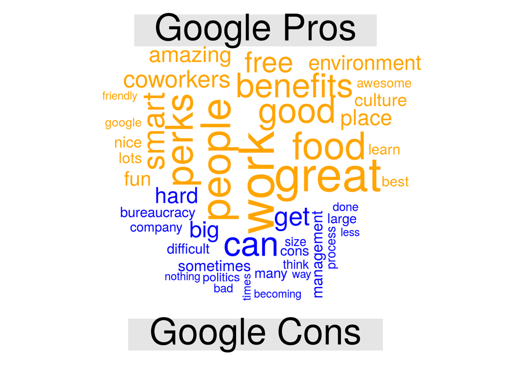

```r
all_google_pros <- paste(google$pros,collapse="")
all_google_cons <- paste(google$cons,collapse = "")

all_google <- c(all_google_pros,all_google_cons)
all_google_qdap <- qdap_clean(all_google)
all_google_vs <- VectorSource(all_google_qdap)
all_google_vc <- VCorpus(all_google_vs)
all_google_clean<- tm_clean(all_google_vc)
all_google_tdm <- TermDocumentMatrix(all_google_clean)
colnames(all_google_tdm) <- c("Google Pros","Google Cons")
all_google_tdm_m <- as.matrix(all_google_tdm)

comparison.cloud(all_google_tdm_m,colors = c("orange","blue"),max.words = 50)
```

Amazon’s positive reviews appear to mention bigrams such as “good benefits”, while its negative reviews focus on bigrams such as “work-life balance” issues.

In contrast to, Google’s positive reviews mention “perks”, “smart people”,“great food”, and “fun culture”, among other things. Google’s negative reviews discuss “politics”, “getting big”, “bureaucracy”, and “middle management”.

Now we’ll make a pyramid plot lining up positive reviews for Amazon and Google so you can adequately see the differences between any shared bigrams.

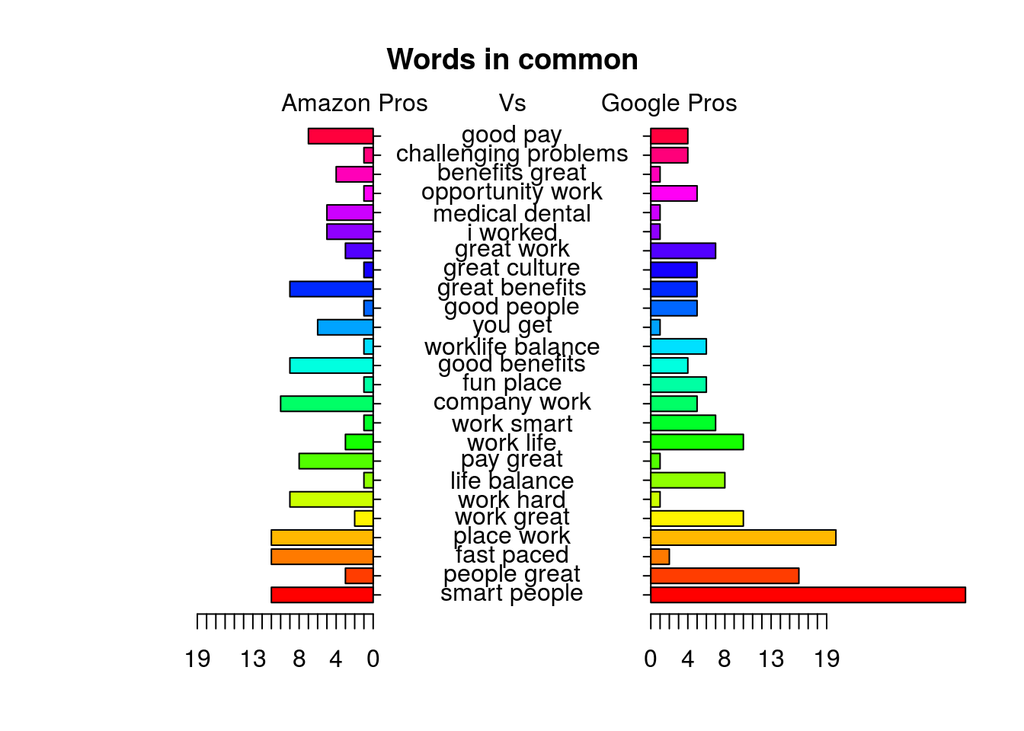

```
## [1] 5.1 4.1 4.1 2.1
```

```r
amazon_pro <- paste(amazon$pros,collapse = "")
google_pro <- paste(google$pros,collapse = "")
all_pro <- c(amazon_pro,google_pro)
all_pro_qdap <- qdap_clean(all_pro)
all_pro_vs <- VectorSource(all_pro)
all_pro_vc <- VCorpus(all_pro_vs)
all_pro_corp <- tm_clean(all_pro_vc)

tdm.bigram = TermDocumentMatrix(all_pro_corp,control = list(tokenize =tokenizer))
colnames(tdm.bigram) <- c("Amazon","Google")
tdm.bigram <- as.matrix(tdm.bigram)
common_words<- subset(tdm.bigram,tdm.bigram[,1] > 0 & tdm.bigram[,2] > 0 )
difference <- abs(common_words[, 1] - common_words[,2])
common_words <- cbind(common_words,difference)
common_words <- common_words[order(common_words[,3],decreasing = TRUE),]
top25_df <- data.frame(x=common_words[1:25,1],y=common_words[1:25,2],labels=rownames(common_words[1:25,]))

library(plotrix)
pyramid.plot(top25_df$x,top25_df$y,labels=top25_df$labels,gap=15,top.labels=c("Amazon Pros","Vs","Google Pros"),unit = NULL,main = "Words in common")
```

You now decide to turn your attention to negative reviews and make the same visuals.

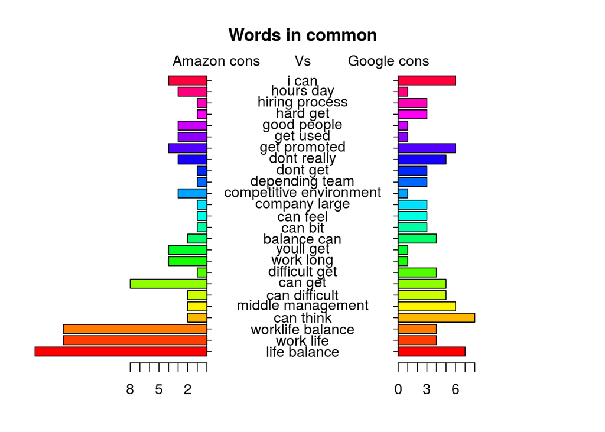

```
## [1] 5.1 4.1 4.1 2.1
```

```r
amazon_cons <- paste(amazon$cons,collapse = "")
google_cons <- paste(google$cons,collapse = "")
all_cons <- c(amazon_cons,google_cons)
all_cons_qdap <- qdap_clean(all_cons)
all_cons_vs <- VectorSource(all_cons)
all_cons_vc <- VCorpus(all_cons_vs)
all_cons_corp <- tm_clean(all_cons_vc)

tdm.cons_bigram = TermDocumentMatrix(all_cons_corp,control=list(tokenize =tokenizer))

colnames(tdm.cons_bigram) <- c("Amazon","Google")
tdm.cons_bigram <- as.matrix(tdm.cons_bigram)
common_words<- subset(tdm.cons_bigram,tdm.cons_bigram[,1] > 0 & tdm.cons_bigram[,2] > 0 )
difference <- abs(common_words[, 1] - common_words[,2])
common_words <- cbind(common_words,difference)
common_words <- common_words[order(common_words[,3],decreasing = TRUE),]
top25_df <- data.frame(x=common_words[1:25,1],y=common_words[1:25,2],labels=rownames(common_words[1:25,]))

library(plotrix)
pyramid.plot(top25_df$x,top25_df$y,labels=top25_df$labels,gap=10,top.labels=c("Amazon cons","Vs","Google cons"),unit = NULL,main = "Words in common")
```

We’ll use Commonality cloud to show common between Aamazon and google with Unigram, Bigram and Trigram tokenizer to identify more insights.

**Unigram**

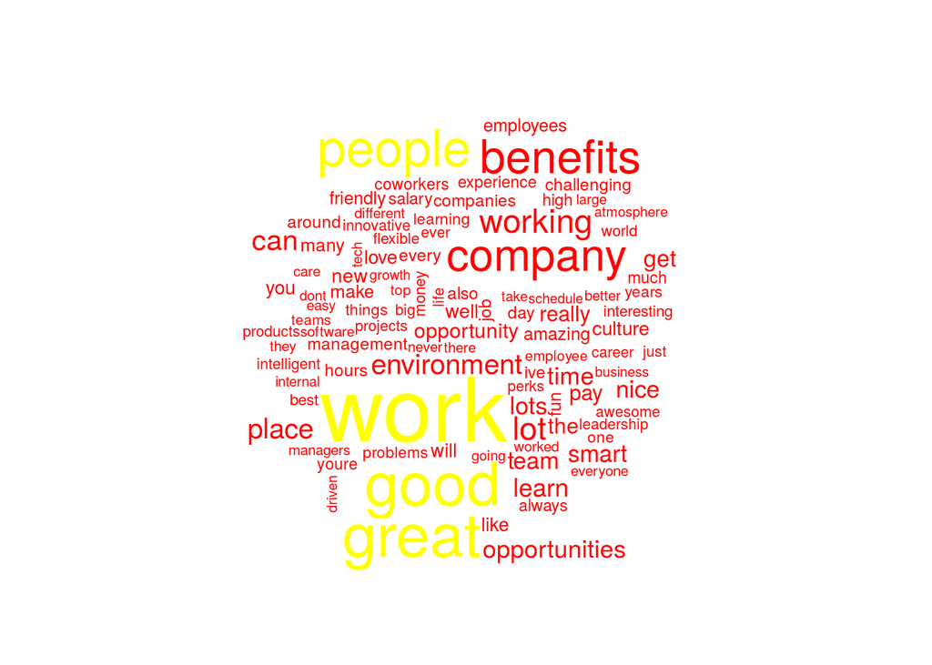

```r
tdm.unigram <- TermDocumentMatrix(all_pro_corp)
colnames(tdm.unigram) <- c("Amazon","Google")
tdm.unigram <- as.matrix(tdm.unigram)

commonality.cloud(tdm.unigram,colors=c("red","yellow"),max.words = 100)
```

**Bigram**

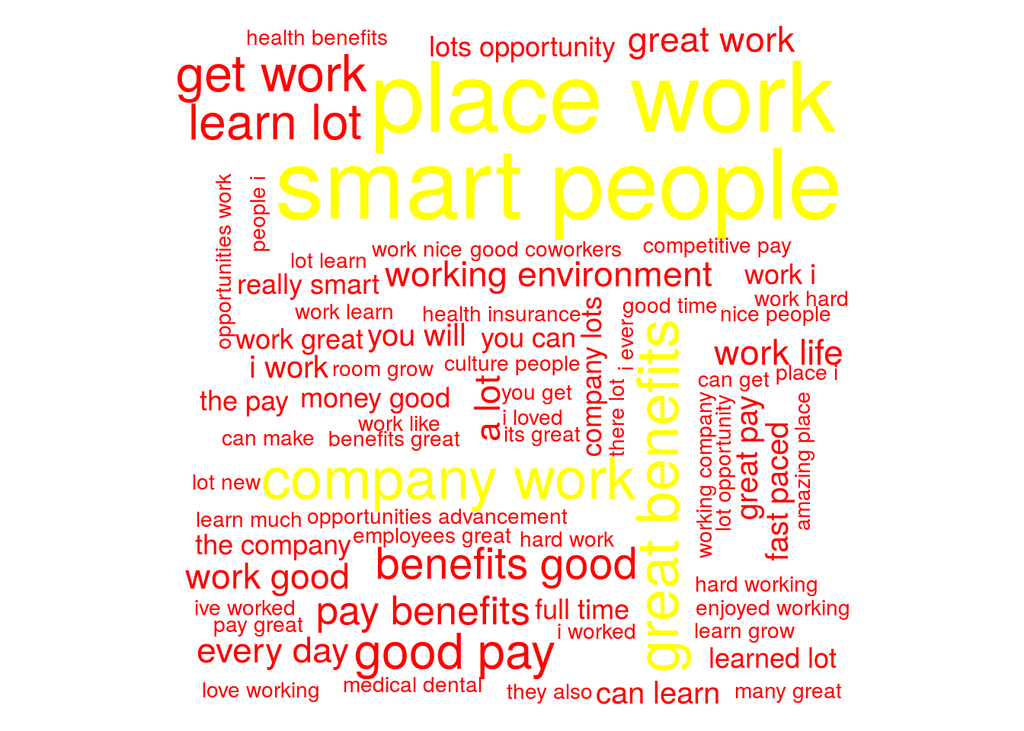

```r
BigramTokenizer <- function(x) NGramTokenizer(x, Weka_control(min = 2, max = 2))
tdm.bigram <- TermDocumentMatrix(all_pro_corp,control = list(tokenize=BigramTokenizer))
colnames(tdm.bigram) <- c("Amazon","Google")
tdm.bigram <- as.matrix(tdm.bigram)

commonality.cloud(tdm.bigram,colors=c("red","yellow"),max.words = 100)
```

**Trigram**

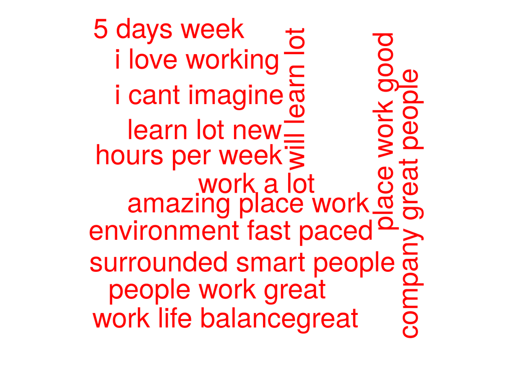

```r
TrigramTokenizer <- function(x) NGramTokenizer(x, Weka_control(min = 3, max = 3))
tdm.trigram <- TermDocumentMatrix(all_pro_corp,control = list(tokenize=TrigramTokenizer))
colnames(tdm.trigram) <- c("Amazon","Google")
tdm.trigram <- as.matrix(tdm.trigram)

commonality.cloud(tdm.trigram,colors=c("red","yellow"),max.words = 100)
```

Plotting amazon and google association

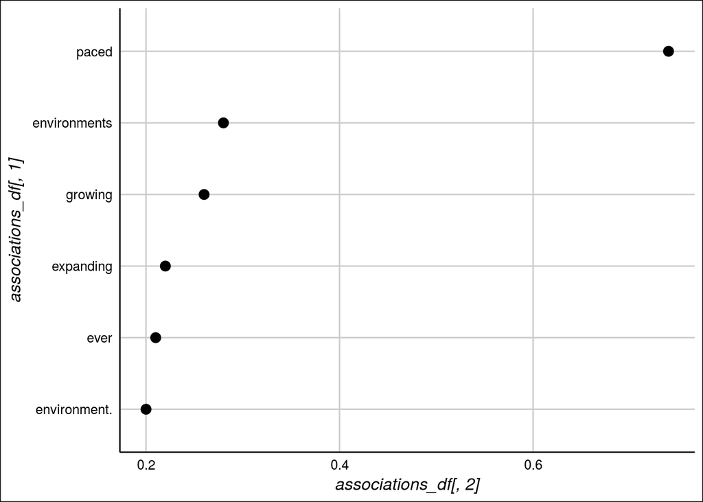

```r
library(ggthemes)
library(ggplot2)

amazon_tdm <- TermDocumentMatrix(amazon_p_corp)
associations <- findAssocs(amazon_tdm,"fast",0.2)
associations_df <- list_vect2df(associations)[,2:3]

ggplot(associations_df,aes(y=associations_df[,1]))+
  geom_point(aes(x=associations_df[,2]),
             data=associations_df,size=3)+
  theme_gdocs()
```

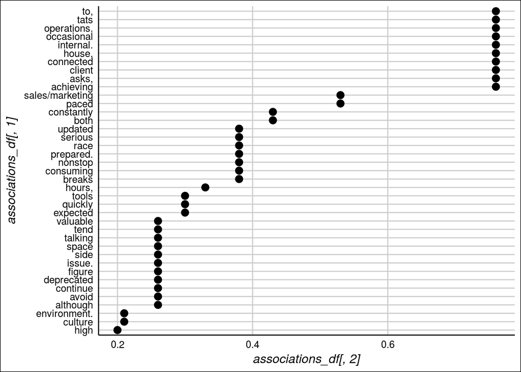

```r
library(ggthemes)
library(ggplot2)

google_tdm <- TermDocumentMatrix(google_c_corp)
associations <- findAssocs(google_tdm,"fast",0.2)
associations_df <- list_vect2df(associations)[,2:3]

ggplot(associations_df,aes(y=associations_df[,1]))+
  geom_point(aes(x=associations_df[,2]),
             data=associations_df,size=3)+
  theme_gdocs()
```

**Conclusion** Google have a better work-life balance according to current employee reviews.

```r
findAssocs(amazon_p_tdm, "fast paced", 0.2)[[1]][1:15]
```

```
## paced environment environments ever        learn fast    paced friendly
##              0.49              0.35              0.35              0.35
##        paced work        able excel    activity ample       advance one
##              0.35              0.25              0.25              0.25
##         also well       amazon fast     amazon noting        amazon one
##              0.25              0.25              0.25              0.25
##       amount time ample opportunity assistance ninety
##              0.25              0.25              0.25
```

We Identified candidates that view an intense workload as an opportunity to learn fast and give them ample opportunity.